# R Notebook

# Packages to be installed

## Import the data from source location:

```r
bookings <- read_csv("C:/Users/sangeeta/Downloads/bookings.csv")
#View(bookings)
```

## Tidy the data

```r
bookings <- bookings %>% drop_na()
```

## Feature Engineering

### Parse Out Day of Week

```r
bookings$DayOfDeparture  = wday(mdy_hm(bookings$DepartureDate,locale = "English"),label = TRUE)
```

### Normalize Fare Per Person

```r
bookings$FarePP = bookings$Fare/bookings$PassengerCount
```

### Convert to FACTOR

```r
bookings$class = as.factor(bookings$InvClass)
bookings$orig = as.factor(bookings$Origin)
bookings$desti = as.factor(bookings$Destination)
```

## Forecasting Fares

### Data Preparation

```r
bookings %>% group_by(orig,desti) %>% tally(sort = TRUE) #indicates DATASET has DTW-LAS as highest number of flights
```

| orig | desti | n |
| --- | --- | --- |
| DTW | LAS | 40833 |
| MSP | LAS | 39681 |
| DTW | MCO | 37887 |
| MSP | MCO | 35350 |
| DTW | LAX | 32428 |
| MSP | LAX | 31270 |
| DTW | TPA | 25197 |
| MSP | SFO | 24329 |
| DTW | ATL | 23572 |
| MSP | DEN | 22892 |

[output cut: 716 more lines]

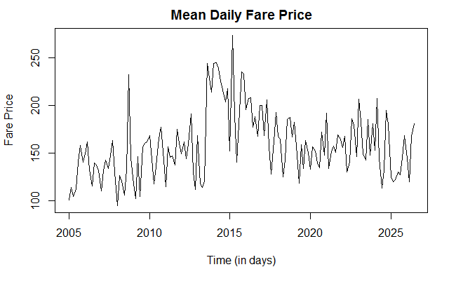

```r
df_LAS = bookings %>% dplyr::filter(orig == 'DTW' & desti == 'LAS') %>%
              select(DepartureDate,FarePP) %>%
              filter(FarePP > 0) %>%
              group_by(DepartureDate) %>%
              summarise(FarePP = mean(FarePP))
df_LAS$DepartureDate = mdy_hm(df_LAS$DepartureDate)
df_LAS$FarePP = round(df_LAS$FarePP,digits = 2)
tsdf_LAS = ts(df_LAS$FarePP, start = c(2005,1),frequency = 7)
# Set frequency of 7 since dataset has only 5 months of data for one year, therefore accounting for weekly seasonality only.
plot(tsdf_LAS,
     lwd=1,
     #xaxt= "n",
     ylab = "Fare Price",
     xlab = "Time (in days)",
     main = "Mean Daily Fare Price")
```

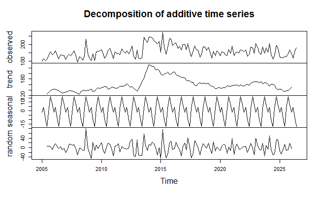

```r
plot(decompose(tsdf_LAS))
```

```r
# Did not use zoo package since there are no arbitrary gaps in the time series
```

### Split Data into 3 - train, test and validation

```r
nValidation = 31
nTrain = length(tsdf_LAS) - nValidation
train.ts = window(tsdf_LAS,start = c(2005,1),end = c(2005,nTrain))
valid.ts = window(tsdf_LAS,start = c(2005,nTrain + 1),end = c(2005,nTrain + nValidation))
```

Naive Forecast (Quadratic model)

```r
AlFc.lm = tslm(train.ts ~ trend + I(trend^2))
AlFc.lm.pred = forecast(AlFc.lm,h = nValidation,level = 0)
plot(AlFc.lm.pred)
lines(AlFc.lm$fitted,lwd = 1)
```

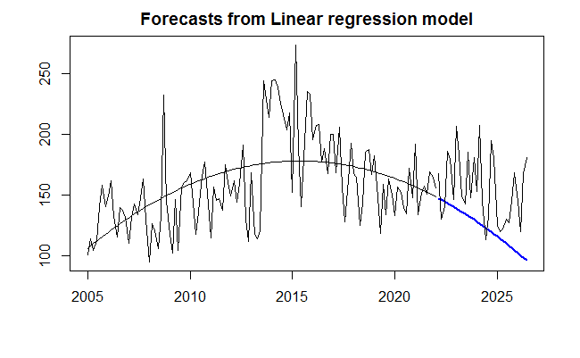

```r
lines(valid.ts)
```

```r
accuracy(AlFc.lm.pred$mean,valid.ts)
```

```
               ME     RMSE      MAE      MPE     MAPE      ACF1 Theil's U
Test set 31.74632 41.83077 33.66933 18.50892 20.04505 0.1685585  1.273043
```

### Smoothing Method - Moving Average

```r
ma.trailing = rollmean(tsdf_LAS,k=12,align = "right") #calculates trailing moving average
ma.centered = ma(tsdf_LAS,order = 12) #creates a centered moving average
plot(tsdf_LAS)
lines(ma.centered,lwd=2)
```

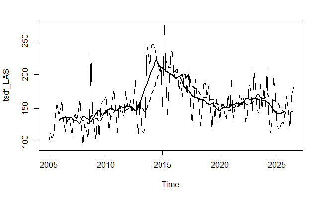

```r
lines(ma.trailing,lwd=2,lty=2)
legend(2005,c("Actual Time Series","Centered Moving Average","Trailing Moving Average"),lty = c(1,1,2),lwd = c(1,2,2), bty = "n")
```

Notice that the seasonality is not captured in the forecast. This is a clear indication that the moving average method can be used for forecasting only in series that lack seasonality and trend. An alternative approach would be to de-trend and deseasonalize the series, use the forecast, and then add trend and seasonality back into the forecast.